Regresión Lineal Simple - Semana 02

Freddy Hernández

fhernanb@unal.edu.co

Profesor Asociado - Departamento de Estadística

Universidad Nacional de Colombia, Sede Medellín

1 / 46

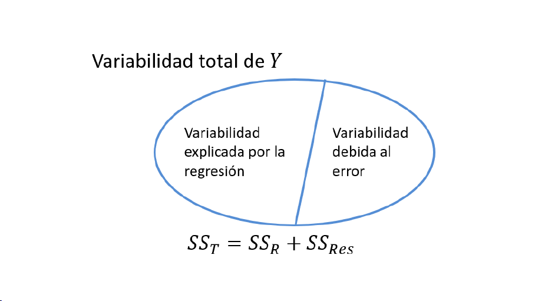

Análisis de varianza para probar la signiﬁcancia de la regresión

2 / 46

Esta prueba de hipótesis es una forma alternativa para estudiar el siguiente conjunto de

hipótesis.

H0:β1=0

H1:β1=0

La prueba se basa en descomponer la variabilidad total observada en Ycomo la suma de

la variabilidad debida al modelo propuesto (recta ajustada) y la variabilidad debida al

error aleatorio.

3 / 46

Recuerde que el modelo de RLS plantea que la respuesta es igual a la suma de una

componente real no aleatoria β0+β1Xy un error aleatorio ε. Se espera que la recta

ajustada explique en forma signiﬁcativa la variabilidad observada en Y.

Para ilustrar el enfoque de análisis de varianza, recuerde que:

SST=Syy =

n

X

i=1

(yi−¯y)2

4 / 46

Las diferencias yi−¯yse pueden escribir como:

yi−¯y= (b

yi−¯y)+(yi−b

yi)

y reemplazando en la SST, se obtiene:

SST=

n

X

i=1

(yi−¯y)2

SST=

n

X

i=1(b

yi−¯y)+(yi−b

yi)2

SST=

n

X

i=1

(b

yi−¯y)2+

n

X

i=1

(yi−b

yi)2

SST=SSR+SSRes

5 / 46

La Suma de Cuadrados de la Regresión (SS

R

) está relacionada con las diferencias entre

los valores ajustados por el modelo de regresión y el promedio de las observaciones de la

respuesta.

Se puede demostrar que:

SSR=

n

X

i=1

(b

yi−¯y)2=b

β1Sxy =b

β2

1Sxx

6 / 46

La Suma de Cuadrados de los Residuales (SSRes ) está relacionada con las diferencias

entre las observaciones de la respuesta y los valores ajustados por el modelo de regresión,

esto es, los residuales del modelo (que son estimaciones de los errores del modelo).

Se puede demostrar que:

SSRes =

n

X

i=1

e2

i=

n

X

i=1

(yi−b

yi)2=Syy −b

β1Sxy

7 / 46

La siguiente expresión

SST=SSR+SSRes ,

se conoce como Identidad de Suma de Cuadrados.

Cada una de estas sumas de cuadrados tiene asociados unos grados de libertad (gl), que

representan la cantidad de información libre en la suma de cuadrados.

Una forma de calcular los gl es la diferencia entre el número de observaciones y el

número de parámetros estimados en la suma de cuadrados.

8 / 46

▶Se sabe que SSTse construye con nobservaciones y se estima la media de la

respuesta con el promedio, de manera que SSTtiene n−1gl.

▶Analizando la expresión para SSRes , se tienen las mismas nobservaciones y se

estiman los dos parámetros del modelo, y así SSRes tiene n−2gl.

▶

Finalmente, SS

R

solo tiene dos observaciones (los estimadores de los parámetros) y

se estima un parámetro, de donde SSRtiene sólo 1 gl.

9 / 46

En virtud de lo anterior, los grados de libertad (gl) de las sumas de cuadrados también

forman una identidad, así:

gl(SST) = gl(SSR) + gl(SSRes )

n−1=1+n−2

A continuación, se deﬁnen los cuadrados medios como la razón entre las sumas de

cuadrados y sus respectivos grados de libertad. Esto es,

▶MSR=SSR/gl(SSR) = SSR/1=SSR.

▶MSRes =SSRes /gl(SSRes ) = SSRes /(n−2).

10 / 46

Con el ﬁn de establecer inferencias basadas en el enfoque del análisis de varianza se

requiere conocer el valor esperado de cada una de los cuadrados medios, es decir, lo que

se estima con cada suma de cuadrados.

Se puede demostrar que:

▶E[MSRes ] = σ2.

▶E[MSR] = σ2+β2

1Sxx .

El primer resultado se conocía de la estimación de σ2vista previamente.

11 / 46

Si todas las observaciones Yiprovienen de la misma distribución normal con media

µ=β0(esto es, si β1=0) y varianza σ2, y además se tiene la identidad de sumas de

cuadrados que establece que SS

T

=SS

R

+SS

Res

, con la respectiva identidad de grados

de libertad (n−1) = 1+ (n−2), entonces:

▶SSR/σ2se distribuye como una variable aleatoria Chi-cuadrado con 1 grado de

libertad.

▶

SS

Res /σ2

se distribuye como una variable aleatoria Chi-cuadrado con n

−

2 grados

de libertad.

▶Los términos SSR/σ2ySSRes /σ2son estimaciones independientes de σ2.

12 / 46

De lo anterior, se considera el siguiente estadístico:

F0=SSR/σ2/1

SSRes /σ2/(n−2)=SSR/1

SSRes /(n−2)=MSR

MSRes

que bajo la hipótesis nula

H0:β1=0

, se distribuye como una Fcon 1 y n

−

2 grados

de libertad:

13 / 46

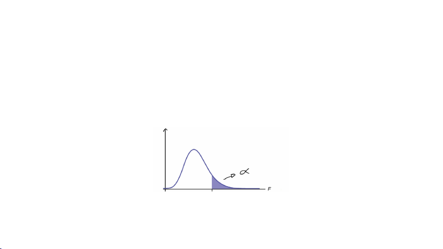

En el caso de la regresión lineal simple, la prueba sobre la signiﬁcancia de la regresión (es

decir, si la pendiente de la recta es signiﬁcativamente diferente de cero) puede realizarse

mediante el análisis de varianza usando un valor crítico Fα;1,n−2de la distribución F.

Esto es, a un nivel de signiﬁcancia αse rechaza la hipótesis nula de que la variabilidad

en la variable respuesta es debida sólo al error aleatorio (en favor de la hipótesis de que

la regresión en Xes signiﬁcativa) si F0>Fα;1,n−2.

14 / 46

[figure not shown]

Resumen de las fórmulas

A continuación las diferentes formas de calcular las sumas de cuadrados necesarias para

el análisis de varianza.

SST=SSy=

n

X

i=1

(yi−¯y)2

SSR=

n

X

i=1

(b

yi−¯y)2=b

β1Sxy =b

β2

1Sxx

SSRes =

n

X

i=1

e2

i=

n

X

i=1

(yi−b

yi)2=SST−SSR

15 / 46

[figure not shown]

Tabla de Análisis de Varianza para el modelo de RLS

Fuente de Suma de Grados de Cuadrado F Valor-p

variación cuadrados libertad medio calculado

Regresión o Modelo SSR1MSR=SSR

1F0=MSR

MSRes

Error o Residual SSRes n−2MSRes =SSRes

n−2

Total SSTn−1

16 / 46

También se puede evaluar el valor-pde la prueba (signiﬁcancia más pequeña que

conduce al rechazo de H0) que es igual a P(F1,n−2>F0)y determinar si es “pequeño”

para rechazar la hipótesis nula: "el modelo lineal de Yen Xno es signiﬁcativo para

explicar la variabilidad de Y".

La conclusión obtenida por el análisis de varianza debe ser la misma que la obtenida

cuando se prueba la signiﬁcancia de la pendiente de la recta de regresión.

17 / 46

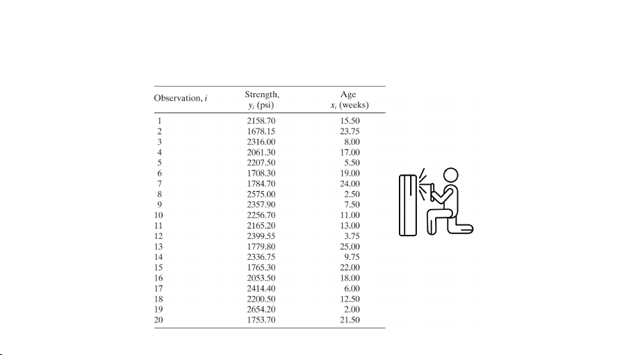

Ejemplo

Aplicar el análisis de varianza para estudiar la signiﬁcancia de la regresión para los datos

de soldadura.

18 / 46

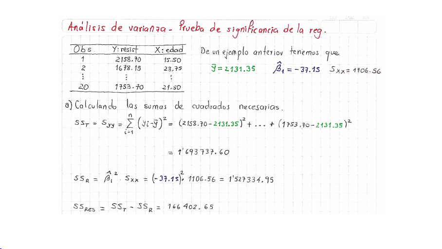

19 / 46

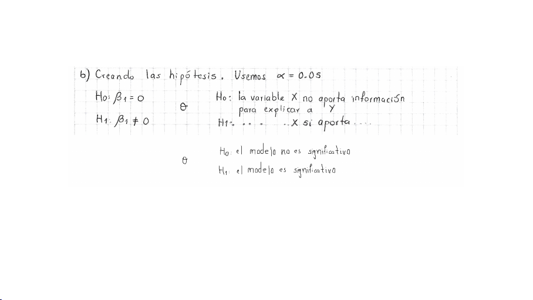

20 / 46

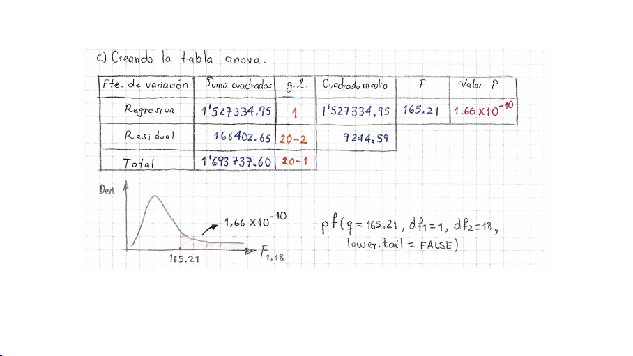

21 / 46

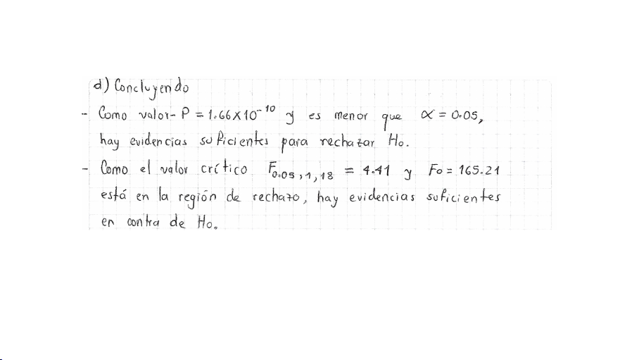

22 / 46

R2de una regresión: Coeﬁciente de determinación muestral

Es una medida del ajuste del modelo que provee un indicador de que tan bien la

predictora Xpredice a la respuesta Y. Se calcula como:

R2=SSR

SST

=1−SSRes

SST

.

El R2se puede interpretar como la proporción de la variabilidad total observada en la

variable respuesta que es explicada por la relación lineal con la variable predictora

considerada.

23 / 46

Interpretaciones erróneas de R2.

▶Un R2alto indica que el modelo puede hacer predicciones útiles.

▶Un R2alto indica que la recta de regresión tiene buen ajuste.

▶Un R2cercano a cero indica que XyYno están relacionados.

Las dos primeras indican que aunque un R2cercano a 1 indica una mayor asociación

lineal, no necesariamente garantiza que los supuestos básicos del modelo lineal se estén

cumpliendo y menos que el modelo lineal no pueda presentar falta de ajuste.

24 / 46

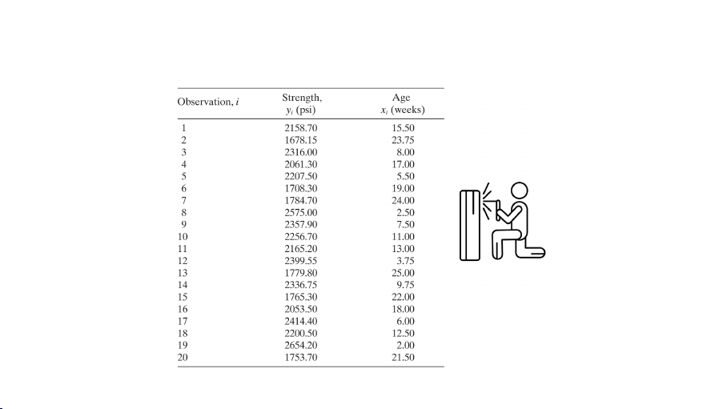

Ejemplo

Calcular el R2para el ejemplo de la soldadura.

25 / 46

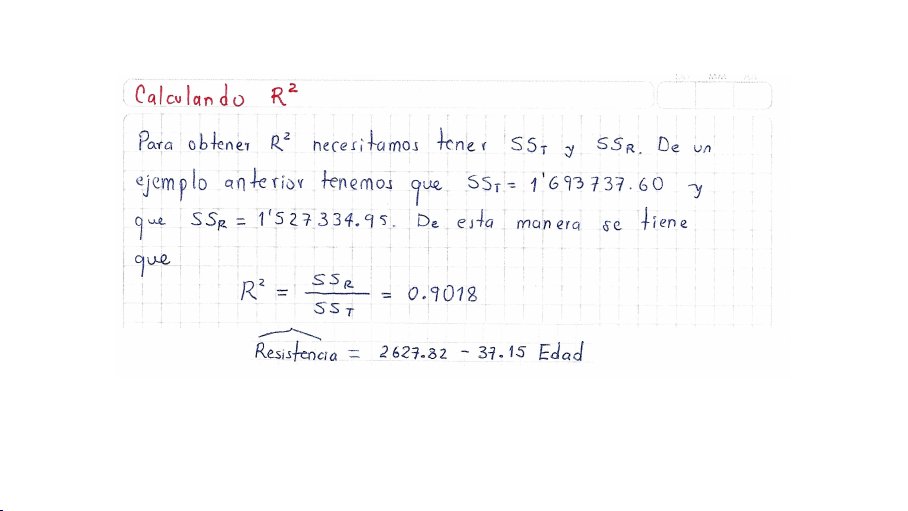

26 / 46

Inferencias sobre la Respuesta Media y sobre Valores Futuros

En esta sección vamos a aprender a:

1. Estimar puntualmente la respuesta media E[Y|x0].

2. Estimar por intervalo la respuesta media E[Y|x0].

3. Estimar puntualmente un valor futuro de Y.

4. Estimar por intervalo un valor futuro de Y.

Esto se va a realizar usando la ecuación de regresión ajustada.

27 / 46

Inferencia sobre la Respuesta Media

La respuesta media para un valor apropiado X=x0se puede denotar de dos maneras,

como E[Y|x0]o como µY|x0.

La respuesta media se puede estimar puntualmente usando la ecuación de regresión

estimada así:

b

E[Y|x0] = b

µY|x0=ˆ

β0+ˆ

β1x0

28 / 46

Como la ecuación de regresión ajustada en un valor dado X=x0, es:

b

Y0=b

β0+b

β1x0,

se puede ver que b

Y0también es una combinación lineal de las variables aleatorias

Y1,...,Yn.en efecto,

b

Y0=b

β0+b

β1x0= n

X

i=1

miYi!+ n

X

i=1

ciYi!x0=

n

X

i=1

(mi+x0ci)Yi,

con las constantes mi=1

n−¯x ciyci=xi−¯x

Sxx como fueron especiﬁcadas previamente.

Por lo tanto, bajo los supuestos del modelo b

Y0es una variable aleatoria normal.

29 / 46

La esperanza de b

Y0es:

Ehb

Y0i=Ehb

β0+b

β1x0i=Ehb

β0i+Ehb

β1ix0=β0+β1x0=E[Y|x0]

y varianza de b

Y0es:

Vhb

Y0i=V"n

X

i=1

(mi+x0ci)Yi#=

n

X

i=1

(mi+x0ci)2V(Yi)

=σ2

n

X

i=11

n−¯xci+x0ci2

=σ2

n

X

i=11

n+ (x0−¯x)ci2

Vhb

Y0i=σ2"1

n+(x0−¯x)2

Sxx #

30 / 46

En resumen,

b

Y0∼N E[Y|x0], σ2"1

n+(x0−¯x)2

Sxx #!

Esto es, b

Y0es un estimador insesgado de la respuesta media.

Note que,

b

Y0

también es un estimador para un valor futuro Y

0

De ahí que la cantidad Y0−b

Y0represente al error de predicción, el cual se sabe tiene

media cero.

31 / 46

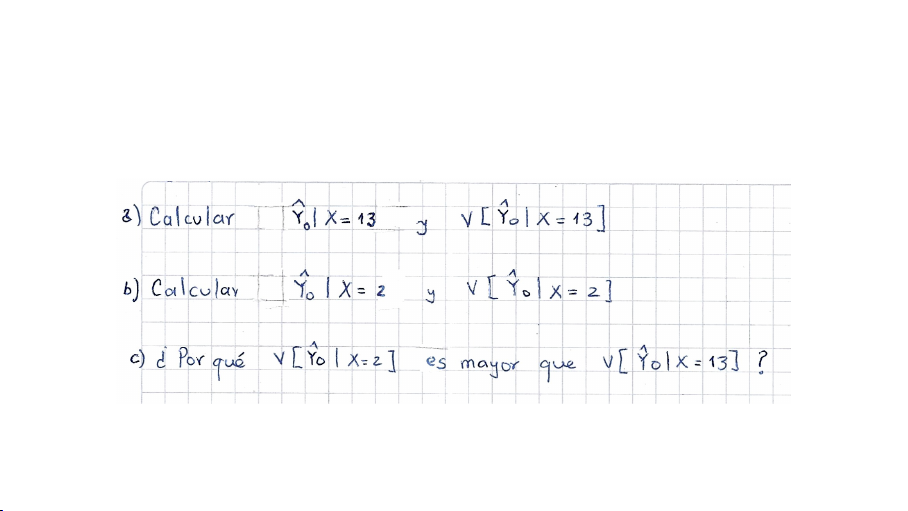

Ejemplo

Para el ejemplo sobre soldadura responder los siguientes literales sobre la respuesta

media µY|x0.

32 / 46

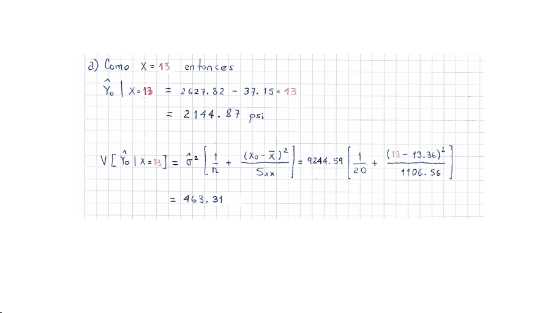

33 / 46

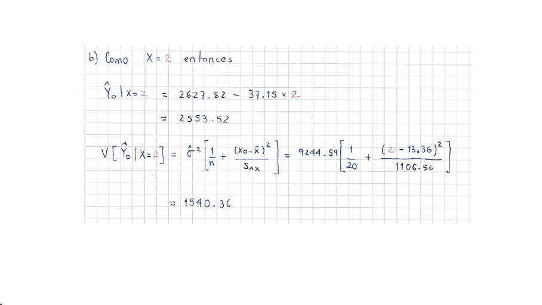

34 / 46

Intervalo de conﬁanza para la respuesta media E[Y|x0] = µY|x0

Se puede demostrar que bajo los supuestos del modelo:

T=b

Y0−E[Y|x0]

rb

σ2h1

n+(x0−¯x)2

Sxx i∼tn−2

Por tanto un intervalo de conﬁanza del (1−α)% para µY|x0es:

b

y0±tα/2,n−2×sb

σ21

n+(x0−¯x)2

Sxx

con b

y0=b

β0+b

β1x0ytα/2,n−2es el percentil 1 −α/2 de la distribución t-Student con

n−2 grados de libertad.

35 / 46

[figure not shown]

El error estándar del estimador ˆµY|x0está dad por:

se(ˆµY|x0) = ˆσ2"1

n+(x0−¯x)2

Sxx #

36 / 46

Ejemplo

Para el ejemplo sobre soldadura calcular un IC del 95 por ciento para la respuesta media

cuando X=13 semanas.

37 / 46

[figure not shown]

38 / 46

Intervalo de predicción para una observación futura Y|x0

Dicho intervalo estima los posibles valores para un valor particular de la variable

respuesta (no para su media) en un valor dado, X=x0. Asumimos que este valor

particular es un valor futuro de la variable aleatoria Yy por tanto, no fue utilizado en la

regresión.

Si

Y0

es un valor futuro y

b

Y0=b

β0+b

β1x0

es su estimador, entonces estas dos variables

aleatorias son estadísticamente independientes, dado que

Y0

no es utilizado para hallar a

b

β0yb

β1.

39 / 46

[figure not shown]

Por tanto, el estadístico:

T=b

Y0−Y0

rb

σ2h1+1

n+(x0−¯x)2

Sxx i∼tn−2

De ahí que, un intervalo de predicción del (1−α)% para Y0está dado por:

b

Y0±tα/2,n−2×sb

σ21+1

n+(x0−¯x)2

Sxx ,

donde

tα/2,n−2

es el percentil

1−α/2

de la distribución t-Student con

n−2

grados de

libertad.

40 / 46

[figure not shown]

El error estándar del estimador ˆ

Y|x0está dado por:

se(ˆ

Y|x0) = ˆσ2"1+1

n+(x0−¯x)2

Sxx #

41 / 46

Ejemplo

Para el ejemplo sobre soldadura calcular un IC del 90 por ciento para una observación

futura cuando X=10 semanas.

42 / 46

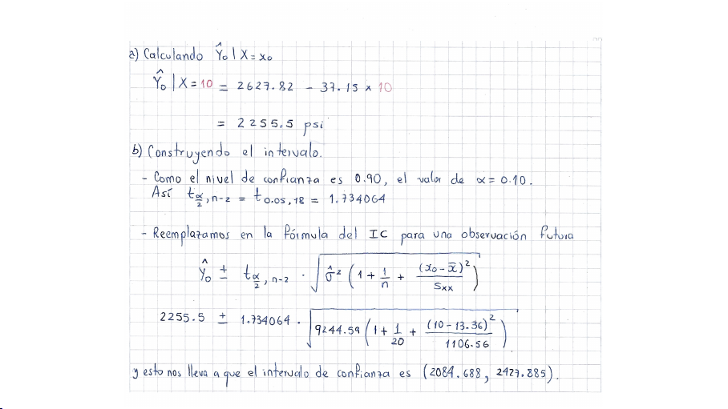

43 / 46

Advertencia

Tanto las estimaciones de valores de la respuesta media como las predicciones de valores

futuros deben cumplir una condición sobre el valor ﬁjo X=x0para que tal

estimación/predicción sea válida.

▶Sólo se podrán hacer inferencias sobre la respuesta cuando X=x0∈[Xmin,Xmax],

donde X

min

yX

max

son los valores mínimo y máximo de la variable predictora, que

fueron ﬁjados en la muestra.

▶Cumplir con lo anterior indica que x0es un punto de interpolación.

▶Esto evita que x0sea un punto de extrapolación, esto es, un punto por fuera del

rango experimental donde el modelo fue ajustado y que no garantiza que el modelo

se mantenga.

44 / 46

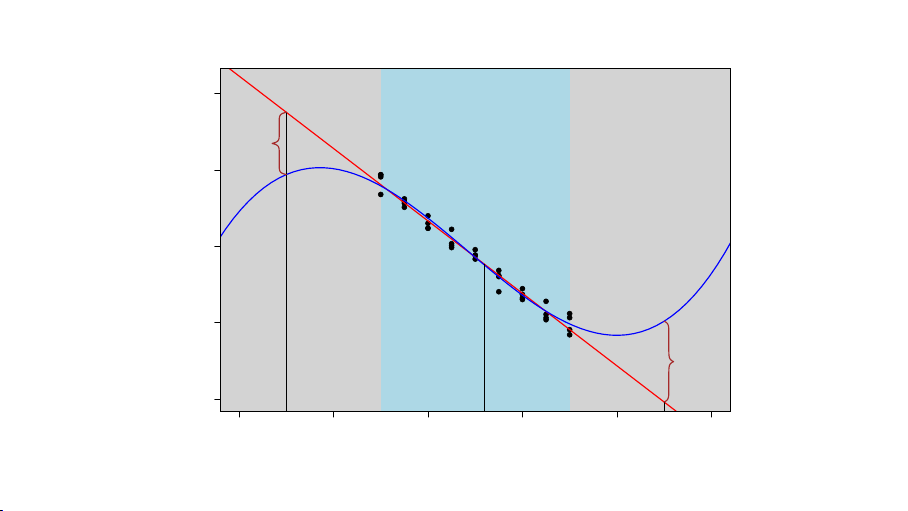

Ilustración de puntos de interpolación y extrapolación

x

y

70 90 110 130 150 170

0 300 600 900 1200

x01 =80 x02 =122 x03 =160

Rango experimental

Zona de

Extrapolación

Zona de

Extrapolación

error

error

45 / 46

Pruebas de hipótesis para la Respuesta Media

Para la respuesta media se pueden probar hipótesis a partir de la construcción y el

análisis de los intervalos de conﬁanza deﬁnidos anteriormente. Esto es, para probar a un

nivel de signiﬁcancia α, el siguiente juego de hipótesis:

H0:E[Y|x0] = c0,

H1:E[Y|x0]=c0,

donde c

0∈R

, se calcula un intervalo de conﬁanza del (1

−α

)100% para E[Y

|

x

0

]y si el

valor c

0

está incluido en el intervalo, entonces no se rechaza H

0

, o si el valor c

0

no está

incluido en el intervalo, entonces se rechaza H0.

46 / 46